# ADNI LOSO Master Audit (Q1 Revision Notebook)

**Ref.** BSPC-D-26-01797  
**Title.** *Stable Network-Level Functional Connectivity Alterations in Alzheimer’s Disease Identified via Interpretable Latent Modelling*  
**Purpose.** This notebook provides a consolidated, publication-grade audit of ADNI LOSO results for the major revision (deadline: **May 29, 2026**).

This master report integrates and improves the prior LOSO notebooks, with explicit focus on reviewer pressure points:

- **Reviewer #1:** site-independence and calibration.
- **Reviewer #3:** imbalance and robustness.
- **Reviewer #5:** methodological rigor and overfitting robustness evidence.

Scope note: this is an **analysis/audit notebook** based on saved artifacts. No retraining is performed.

## 1. Configuration and Robust Path Resolution

The code below:

- detects repository root dynamically,
- resolves results from either `results/revision_bspc_2026/` (preferred) or `notebooks/revision_bspc_2026/results/revision_bspc_2026/` (fallback),
- reports exactly which artifacts were found or missing,
- prepares figure/table export directories used consistently throughout this notebook.

```python
from pathlib import Path
import json
import warnings
import sys

import numpy as np
import pandas as pd
import matplotlib.pyplot as plt
from matplotlib.lines import Line2D
from matplotlib.patches import Ellipse

from IPython.display import display, Markdown

# --- Lightweight bootstrap to import helper module even before repo detection ---
def _quick_find_repo_root(start=None, max_levels: int = 10) -> Path:
    start_path = (start or Path.cwd()).resolve()
    for c in [start_path, *list(start_path.parents)[:max_levels]]:
        if (c / "data").exists() and (c / "scripts" / "revision_bspc_2026").exists():
            return c
    fallback = Path("/home/diego/proyectos/vae_AD").resolve()
    if fallback.exists():
        return fallback
    raise FileNotFoundError("Could not detect repository root.")

REPO_ROOT = _quick_find_repo_root()
sys.path.insert(0, str(REPO_ROOT / "scripts" / "revision_bspc_2026"))

from loso_master_q1_helpers import (
    find_repo_root,
    results_root_candidates,
    resolve_artifact,
    build_artifact_diagnostic,
    load_csv_optional,
    load_json_optional,
    ensure_dir,
    parse_site_series,
    site_to_int,
    standardized_mean_difference,
    bootstrap_auc_ci,
    calibration_slope_intercept,
    expected_calibration_error,
    setup_pub_style,
    export_figure,
)

setup_pub_style()

REPO_ROOT = find_repo_root(REPO_ROOT)
RESULTS_ROOTS = results_root_candidates(REPO_ROOT)

DATA_DIR = REPO_ROOT / "data"
NOTEBOOK_DIR = REPO_ROOT / "notebooks" / "revision_bspc_2026"

METADATA_PATH = DATA_DIR / "SubjectsData_AAL3_procesado2.csv"
TENSOR_PATH = (
    DATA_DIR
    / "AAL3_dynamicROIs_fmri_tensor_NeuroEnhanced_v6.5.17_AAL3_131ROIs_OMST_GCE_Signed_GrangerLag1_ChNorm_ROIreorderedYeo17_ParallelTuned"
    / "GLOBAL_TENSOR_from_AAL3_dynamicROIs_fmri_tensor_NeuroEnhanced_v6.5.17_AAL3_131ROIs_OMST_GCE_Signed_GrangerLag1_ChNorm_ROIreorderedYeo17_ParallelTuned.npz"
)

FIG_DIR = ensure_dir(REPO_ROOT / "results" / "revision_bspc_2026" / "figures_loso_master_q1")
TABLE_DIR = ensure_dir(REPO_ROOT / "results" / "revision_bspc_2026" / "tables_loso_master_q1")

SITE_ORDER_PRIMARY = [6, 18, 19, 130, 305]
SITE_ORDER_STRICT = [6, 130]
FAIL_SITE = 305
CHANNELS_TO_USE = [1, 0, 2]

COLORS = {
    "logreg": "#1f77b4",
    "svm": "#ff7f0e",
    "cn": "#4C78A8",
    "ad": "#D62728",
    "site305": "#C44E52",
    "neutral": "#9AA0A6",
}

ARTIFACT_RELPATHS = {
    # Site audit
    "site_by_class_cn_ad": "site_audit/site_by_class_cn_ad.csv",
    "class_by_manufacturer": "site_audit/class_by_manufacturer.csv",
    "site_loso_feasibility": "site_audit/site_loso_feasibility.csv",
    # Scanner leakage
    "scanner_leakage_aggregate": "scanner_leakage/scanner_leakage_aggregate.csv",
    # LOSO primary
    "loso_primary_site_metrics": "loso_primary/loso_site_metrics.csv",
    "loso_primary_all_predictions": "loso_primary/loso_all_predictions.csv",
    "loso_primary_pooled_metrics": "loso_primary/pooled_metrics.json",
    "loso_primary_calibration_curve": "loso_primary/pooled_calibration_curve.csv",
    # LOSO strict
    "loso_strict_site_metrics": "loso_strict/loso_site_metrics.csv",
    "loso_strict_all_predictions": "loso_strict/loso_all_predictions.csv",
    "loso_strict_pooled_metrics": "loso_strict/pooled_metrics.json",
    # LOSO primary + SVM sensitivity
    "loso_primary_svm_site_metrics": "loso_primary_svm/loso_site_metrics.csv",
    "loso_primary_svm_all_predictions": "loso_primary_svm/loso_all_predictions.csv",
    "loso_primary_svm_pooled_metrics": "loso_primary_svm/pooled_metrics.json",
}

artifact_diag = build_artifact_diagnostic(ARTIFACT_RELPATHS, RESULTS_ROOTS)
artifact_paths = {
    key: resolve_artifact(rel, RESULTS_ROOTS)
    for key, rel in ARTIFACT_RELPATHS.items()
}

print(f"REPO_ROOT: {REPO_ROOT}")
print("RESULTS_ROOT candidates:")
for r in RESULTS_ROOTS:
    print(f"  - {r} {'(exists)' if r.exists() else '(missing)'}")
print(f"FIG_DIR: {FIG_DIR}")
print(f"TABLE_DIR: {TABLE_DIR}")

if not METADATA_PATH.exists():
    raise FileNotFoundError(f"Missing metadata file: {METADATA_PATH}")
if not TENSOR_PATH.exists():
    raise FileNotFoundError(f"Missing tensor file: {TENSOR_PATH}")

display(artifact_diag)

missing = artifact_diag.loc[artifact_diag["status"] == "missing", "artifact"].tolist()
if missing:
    warnings.warn(
        "Some optional artifacts are missing and corresponding sections may be reduced: "
        + ", ".join(missing)
    )
```

```
REPO_ROOT: /home/diego/proyectos/vae_AD
RESULTS_ROOT candidates:
  - /home/diego/proyectos/vae_AD/results/revision_bspc_2026 (exists)
  - /home/diego/proyectos/vae_AD/notebooks/revision_bspc_2026/results/revision_bspc_2026 (exists)
FIG_DIR: /home/diego/proyectos/vae_AD/results/revision_bspc_2026/figures_loso_master_q1
TABLE_DIR: /home/diego/proyectos/vae_AD/results/revision_bspc_2026/tables_loso_master_q1
```

|  | artifact | relative_path | status | resolved_path |
| --- | --- | --- | --- | --- |
| 0 | site_by_class_cn_ad | site_audit/site_by_class_cn_ad.csv | found | /home/diego/proyectos/vae_AD/results/revision_... |
| 1 | class_by_manufacturer | site_audit/class_by_manufacturer.csv | found | /home/diego/proyectos/vae_AD/results/revision_... |
| 2 | site_loso_feasibility | site_audit/site_loso_feasibility.csv | found | /home/diego/proyectos/vae_AD/results/revision_... |
| 3 | scanner_leakage_aggregate | scanner_leakage/scanner_leakage_aggregate.csv | found | /home/diego/proyectos/vae_AD/results/revision_... |
| 4 | loso_primary_site_metrics | loso_primary/loso_site_metrics.csv | found | /home/diego/proyectos/vae_AD/notebooks/revisio... |
| 5 | loso_primary_all_predictions | loso_primary/loso_all_predictions.csv | found | /home/diego/proyectos/vae_AD/notebooks/revisio... |
| 6 | loso_primary_pooled_metrics | loso_primary/pooled_metrics.json | found | /home/diego/proyectos/vae_AD/notebooks/revisio... |
| 7 | loso_primary_calibration_curve | loso_primary/pooled_calibration_curve.csv | found | /home/diego/proyectos/vae_AD/notebooks/revisio... |
| 8 | loso_strict_site_metrics | loso_strict/loso_site_metrics.csv | found | /home/diego/proyectos/vae_AD/notebooks/revisio... |
| 9 | loso_strict_all_predictions | loso_strict/loso_all_predictions.csv | found | /home/diego/proyectos/vae_AD/notebooks/revisio... |
| 10 | loso_strict_pooled_metrics | loso_strict/pooled_metrics.json | found | /home/diego/proyectos/vae_AD/notebooks/revisio... |
| 11 | loso_primary_svm_site_metrics | loso_primary_svm/loso_site_metrics.csv | found | /home/diego/proyectos/vae_AD/notebooks/revisio... |
| 12 | loso_primary_svm_all_predictions | loso_primary_svm/loso_all_predictions.csv | found | /home/diego/proyectos/vae_AD/notebooks/revisio... |
| 13 | loso_primary_svm_pooled_metrics | loso_primary_svm/pooled_metrics.json | found | /home/diego/proyectos/vae_AD/notebooks/revisio... |

## 1.1 Data Loading

We load metadata, tensor descriptors, and all available revision artifacts.

```python
meta = pd.read_csv(METADATA_PATH)
meta["Site3"] = pd.to_numeric(meta["Site3"], errors="coerce")
if "tensor_idx" in meta.columns:
    meta["tensor_idx"] = pd.to_numeric(meta["tensor_idx"], errors="coerce")

with np.load(TENSOR_PATH, allow_pickle=True) as npz:
    global_tensor = npz["global_tensor_data"]
    tensor_subject_ids = npz["subject_ids"]
    channel_names = npz["channel_names"] if "channel_names" in npz else None
    roi_names = npz["roi_names_in_order"]

# Load all artifacts that are present
site_by_class_cn_ad = load_csv_optional(artifact_paths["site_by_class_cn_ad"])
class_by_manufacturer = load_csv_optional(artifact_paths["class_by_manufacturer"])
site_loso_feasibility = load_csv_optional(artifact_paths["site_loso_feasibility"])
scanner_leakage_agg = load_csv_optional(artifact_paths["scanner_leakage_aggregate"])

loso_primary_metrics = load_csv_optional(artifact_paths["loso_primary_site_metrics"])
loso_primary_preds = load_csv_optional(artifact_paths["loso_primary_all_predictions"])
loso_primary_pooled = load_json_optional(artifact_paths["loso_primary_pooled_metrics"])
loso_primary_cal_curve = load_csv_optional(artifact_paths["loso_primary_calibration_curve"])

loso_strict_metrics = load_csv_optional(artifact_paths["loso_strict_site_metrics"])
loso_strict_preds = load_csv_optional(artifact_paths["loso_strict_all_predictions"])
loso_strict_pooled = load_json_optional(artifact_paths["loso_strict_pooled_metrics"])

loso_primary_svm_metrics = load_csv_optional(artifact_paths["loso_primary_svm_site_metrics"])
loso_primary_svm_preds = load_csv_optional(artifact_paths["loso_primary_svm_all_predictions"])
loso_primary_svm_pooled = load_json_optional(artifact_paths["loso_primary_svm_pooled_metrics"])

print(f"Metadata shape: {meta.shape}")
print(f"Global tensor shape: {global_tensor.shape}")
print(f"Tensor subjects: {len(tensor_subject_ids)}")

print("\nPrimary LOSO loaded:", loso_primary_metrics is not None, loso_primary_preds is not None, loso_primary_pooled is not None)
print("Strict LOSO loaded:", loso_strict_metrics is not None, loso_strict_preds is not None, loso_strict_pooled is not None)
print("Primary+SVM loaded:", loso_primary_svm_metrics is not None, loso_primary_svm_preds is not None, loso_primary_svm_pooled is not None)

# Minimal fallbacks for key audit tables if CSVs are missing
meta_cn_ad = meta[meta["ResearchGroup_Mapped"].isin(["CN", "AD"])].copy()
if class_by_manufacturer is None:
    class_by_manufacturer = (
        meta_cn_ad.groupby(["Manufacturer", "ResearchGroup_Mapped"])
        .size()
        .unstack(fill_value=0)
        .reset_index()
    )
    for c in ["CN", "AD"]:
        if c not in class_by_manufacturer:
            class_by_manufacturer[c] = 0
    class_by_manufacturer["total"] = class_by_manufacturer["CN"] + class_by_manufacturer["AD"]

if site_by_class_cn_ad is None and loso_primary_preds is not None:
    tmp = loso_primary_preds[["SubjectID", "y_true", "site"]].copy()
    tmp["Site3"] = parse_site_series(tmp["site"])
    tmp["class"] = tmp["y_true"].map({0: "CN", 1: "AD"})
    site_by_class_cn_ad = tmp.groupby(["Site3", "class"]).size().unstack(fill_value=0).reset_index()
    for c in ["CN", "AD"]:
        if c not in site_by_class_cn_ad:
            site_by_class_cn_ad[c] = 0
    site_by_class_cn_ad["total"] = site_by_class_cn_ad["CN"] + site_by_class_cn_ad["AD"]
```

```
Metadata shape: (434, 33)
Global tensor shape: (431, 7, 131, 131)
Tensor subjects: 431

Primary LOSO loaded: True True True
Strict LOSO loaded: True True True
Primary+SVM loaded: True True True
```

## 2. Executive Summary

The table below focuses on three runs:

- `primary_logreg` (headline analysis)
- `strict_logreg` (complementary sensitivity)
- `primary_with_svm` (secondary classifier sensitivity)

```python
def _pooled_to_df(obj):
    if obj is None:
        return None
    if isinstance(obj, list):
        return pd.DataFrame(obj)
    return pd.DataFrame([obj])

def _extract_pooled(pooled_obj, classifier_type):
    df = _pooled_to_df(pooled_obj)
    if df is None or df.empty:
        return None
    if "classifier_type" in df.columns:
        sub = df[df["classifier_type"] == classifier_type]
        if not sub.empty:
            return sub.iloc[0].to_dict()
    return df.iloc[0].to_dict()

rows = []

primary_row = _extract_pooled(loso_primary_pooled, "logreg")
if primary_row is not None:
    rows.append(
        {
            "run": "primary_logreg",
            "classifier_type": primary_row.get("classifier_type", "logreg"),
            "pooled_auc_final": primary_row.get("pooled_auc_final", np.nan),
            "pooled_pr_auc_final": primary_row.get("pooled_pr_auc_final", np.nan),
            "pooled_balanced_accuracy": primary_row.get("pooled_balanced_accuracy", np.nan),
            "pooled_brier_final": primary_row.get("pooled_brier_final", np.nan),
            "n_total": primary_row.get("n_total", np.nan),
        }
    )

strict_row = _extract_pooled(loso_strict_pooled, "logreg")
if strict_row is not None:
    rows.append(
        {
            "run": "strict_logreg",
            "classifier_type": strict_row.get("classifier_type", "logreg"),
            "pooled_auc_final": strict_row.get("pooled_auc_final", np.nan),
            "pooled_pr_auc_final": strict_row.get("pooled_pr_auc_final", np.nan),
            "pooled_balanced_accuracy": strict_row.get("pooled_balanced_accuracy", np.nan),
            "pooled_brier_final": strict_row.get("pooled_brier_final", np.nan),
            "n_total": strict_row.get("n_total", np.nan),
        }
    )

svm_row = _extract_pooled(loso_primary_svm_pooled, "svm")
if svm_row is not None:
    rows.append(
        {
            "run": "primary_with_svm",
            "classifier_type": svm_row.get("classifier_type", "svm"),
            "pooled_auc_final": svm_row.get("pooled_auc_final", np.nan),
            "pooled_pr_auc_final": svm_row.get("pooled_pr_auc_final", np.nan),
            "pooled_balanced_accuracy": svm_row.get("pooled_balanced_accuracy", np.nan),
            "pooled_brier_final": svm_row.get("pooled_brier_final", np.nan),
            "n_total": svm_row.get("n_total", np.nan),
        }
    )

executive_summary = pd.DataFrame(rows)
if not executive_summary.empty:
    executive_summary = executive_summary[
        [
            "run",
            "classifier_type",
            "pooled_auc_final",
            "pooled_pr_auc_final",
            "pooled_balanced_accuracy",
            "pooled_brier_final",
            "n_total",
        ]
    ]
    executive_summary.to_csv(TABLE_DIR / "executive_summary_loso_master_q1.csv", index=False)

display(executive_summary.style.format(
    {
        "pooled_auc_final": "{:.3f}",
        "pooled_pr_auc_final": "{:.3f}",
        "pooled_balanced_accuracy": "{:.3f}",
        "pooled_brier_final": "{:.3f}",
        "n_total": "{:.0f}",
    }
))

# Sanity checks (not hard constraints; just coherence flags)
sanity_rows = []
if not executive_summary.empty:
    run_map = {r["run"]: r for _, r in executive_summary.iterrows()}

    if "primary_logreg" in run_map:
        val = float(run_map["primary_logreg"]["pooled_auc_final"])
        sanity_rows.append({"check": "primary_logreg pooled AUC near expected (~0.68)", "value": val, "pass": abs(val - 0.68) <= 0.10})
    if "strict_logreg" in run_map:
        val = float(run_map["strict_logreg"]["pooled_auc_final"])
        sanity_rows.append({"check": "strict_logreg pooled AUC near expected (~0.66)", "value": val, "pass": abs(val - 0.66) <= 0.10})
    if loso_primary_metrics is not None:
        site305 = loso_primary_metrics.copy()
        if "site" in site305.columns:
            row305 = site305[parse_site_series(site305["site"]) == 305]
            if not row305.empty:
                v = float(row305.iloc[0]["auc_final"])
                sanity_rows.append({"check": "site_305 AUC near expected (~0.25)", "value": v, "pass": abs(v - 0.25) <= 0.20})
    if {"primary_logreg", "primary_with_svm"}.issubset(run_map.keys()):
        v_log = float(run_map["primary_logreg"]["pooled_auc_final"])
        v_svm = float(run_map["primary_with_svm"]["pooled_auc_final"])
        sanity_rows.append({"check": "logreg pooled AUC >= svm pooled AUC", "value": v_log - v_svm, "pass": v_log >= v_svm})

sanity_df = pd.DataFrame(sanity_rows)
if not sanity_df.empty:
    display(sanity_df)

if not executive_summary.empty:
    p = executive_summary.set_index("run")
    if "primary_logreg" in p.index:
        txt = (
            f"Primary LOSO (logreg) pooled AUC={p.loc['primary_logreg', 'pooled_auc_final']:.3f}, "
            f"PR-AUC={p.loc['primary_logreg', 'pooled_pr_auc_final']:.3f}, "
            f"balanced accuracy={p.loc['primary_logreg', 'pooled_balanced_accuracy']:.3f}."
        )
        display(Markdown("**Interpretation.** " + txt))
```

|  | run | classifier_type | pooled_auc_final | pooled_pr_auc_final | pooled_balanced_accuracy | pooled_brier_final | n_total |
| --- | --- | --- | --- | --- | --- | --- | --- |
| 0 | primary_logreg | logreg | 0.681 | 0.634 | 0.625 | 0.231 | 76 |
| 1 | strict_logreg | logreg | 0.665 | 0.574 | 0.556 | 0.221 | 47 |
| 2 | primary_with_svm | svm | 0.636 | 0.590 | 0.590 | 0.241 | 76 |

|  | check | value | pass |
| --- | --- | --- | --- |
| 0 | primary_logreg pooled AUC near expected (~0.68) | 0.681466 | True |
| 1 | strict_logreg pooled AUC near expected (~0.66) | 0.664751 | True |
| 2 | site_305 AUC near expected (~0.25) | 0.250000 | True |
| 3 | logreg pooled AUC >= svm pooled AUC | 0.045807 | True |

**Interpretation.** Primary LOSO (logreg) pooled AUC=0.681, PR-AUC=0.634, balanced accuracy=0.625.

## 3. Cohort Audit: Why Philips-Only LOSO Is Necessary

This section addresses the core design constraint explicitly: LOSO is restricted to Philips because CN subjects are Philips-only in the AD/CN cohort.

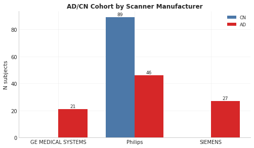

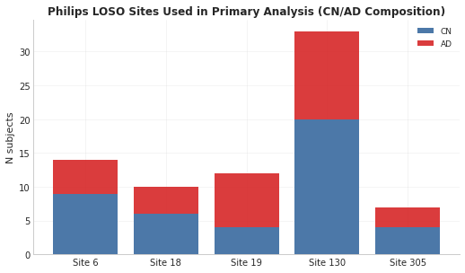

|  | site | CN | AD | total |
| --- | --- | --- | --- | --- |
| 1 | 6 | 9 | 5 | 14 |
| 4 | 18 | 6 | 4 | 10 |
| 3 | 19 | 4 | 8 | 12 |
| 0 | 130 | 20 | 13 | 33 |
| 7 | 305 | 4 | 3 | 7 |

|  | site | CN | AD | total | has_both_classes | main_loso | sensitivity_loso | loso_set | exclusion_reason |
| --- | --- | --- | --- | --- | --- | --- | --- | --- | --- |
| 0 | 100 | 11 | 2 | 13 | True | False | False | excluded | too small (min class n=2, need 3 for sensitivi... |
| 1 | 168 | 0 | 8 | 8 | False | False | False | excluded | single class only |
| 2 | 2 | 7 | 0 | 7 | False | False | False | excluded | single class only |
| 3 | 177 | 6 | 0 | 6 | False | False | False | excluded | single class only |
| 4 | 123 | 4 | 2 | 6 | True | False | False | excluded | too small (min class n=2, need 3 for sensitivi... |
| 5 | 135 | 0 | 6 | 6 | False | False | False | excluded | single class only |
| 6 | 13 | 3 | 2 | 5 | True | False | False | excluded | too small (min class n=2, need 3 for sensitivi... |
| 7 | 31 | 4 | 1 | 5 | True | False | False | excluded | too small (min class n=1, need 3 for sensitivi... |
| 8 | 136 | 4 | 1 | 5 | True | False | False | excluded | too small (min class n=1, need 3 for sensitivi... |
| 9 | 27 | 0 | 4 | 4 | False | False | False | excluded | single class only |
| 10 | 35 | 0 | 4 | 4 | False | False | False | excluded | single class only |
| 11 | 53 | 1 | 3 | 4 | True | False | False | excluded | too small (min class n=1, need 3 for sensitivi... |
| 12 | 301 | 3 | 1 | 4 | True | False | False | excluded | too small (min class n=1, need 3 for sensitivi... |
| 13 | 32 | 0 | 3 | 3 | False | False | False | excluded | single class only |
| 14 | 98 | 0 | 3 | 3 | False | False | False | excluded | single class only |

**Take-home message.** LOSO across all manufacturers is not interpretable in this cohort because CN is absent from GE/SIEMENS; therefore, the defensible LOSO analysis is Philips-only.

```python
# Manufacturer x diagnosis counts
mfg = class_by_manufacturer.copy()
for c in ["CN", "AD"]:
    if c not in mfg.columns:
        mfg[c] = 0
mfg = mfg.sort_values("Manufacturer")

x = np.arange(len(mfg))
width = 0.38

fig, ax = plt.subplots(figsize=(8.2, 4.6))
b1 = ax.bar(x - width / 2, mfg["CN"].values, width=width, color=COLORS["cn"], label="CN")
b2 = ax.bar(x + width / 2, mfg["AD"].values, width=width, color=COLORS["ad"], label="AD")

for bars in [b1, b2]:
    for b in bars:
        if b.get_height() > 0:
            ax.text(b.get_x() + b.get_width() / 2, b.get_height() + 0.5, f"{int(b.get_height())}", ha="center", va="bottom", fontsize=9)

ax.set_xticks(x)
ax.set_xticklabels(mfg["Manufacturer"].tolist(), rotation=0)
ax.set_ylabel("N subjects")
ax.set_title("AD/CN Cohort by Scanner Manufacturer")
ax.legend(frameon=False)

export_figure(fig, FIG_DIR, "03_manufacturer_by_class")
plt.show()

# Philips LOSO site composition
if site_by_class_cn_ad is not None:
    site_counts = site_by_class_cn_ad.copy()
    site_counts["Site3"] = pd.to_numeric(site_counts["Site3"], errors="coerce")
    for c in ["CN", "AD"]:
        if c not in site_counts.columns:
            site_counts[c] = 0
    site_counts = site_counts[site_counts["Site3"].isin(SITE_ORDER_PRIMARY)].copy()
    site_counts["site_order"] = site_counts["Site3"].map({s: i for i, s in enumerate(SITE_ORDER_PRIMARY)})
    site_counts = site_counts.sort_values("site_order")

    fig, ax = plt.subplots(figsize=(8.5, 4.8))
    xx = np.arange(len(site_counts))
    ax.bar(xx, site_counts["CN"], color=COLORS["cn"], label="CN")
    ax.bar(xx, site_counts["AD"], bottom=site_counts["CN"], color=COLORS["ad"], label="AD", alpha=0.9)

    ax.set_xticks(xx)
    ax.set_xticklabels([f"Site {int(s)}" for s in site_counts["Site3"]])
    ax.set_ylabel("N subjects")
    ax.set_title("Philips LOSO Sites Used in Primary Analysis (CN/AD Composition)")
    ax.legend(frameon=False)

    export_figure(fig, FIG_DIR, "03_philips_loso_site_composition")
    plt.show()

    display(site_counts[["Site3", "CN", "AD", "total"]].rename(columns={"Site3": "site"}))

# LOSO feasibility summary table
if site_loso_feasibility is not None:
    feas = site_loso_feasibility.copy()
    feasible_view = feas[[
        "site", "CN", "AD", "total", "has_both_classes", "main_loso", "sensitivity_loso", "loso_set", "exclusion_reason"
    ]].sort_values(["loso_set", "total"], ascending=[True, False])
    feasible_view.to_csv(TABLE_DIR / "03_site_loso_feasibility_summary.csv", index=False)
    display(feasible_view.head(15))

display(Markdown(
    "**Take-home message.** LOSO across all manufacturers is not interpretable in this cohort because CN is absent from GE/SIEMENS; therefore, the defensible LOSO analysis is Philips-only."
))
```

## 4. Scanner Leakage Context

Manufacturer identity remains decodable from both connectome and latent representations in held-out test data (above chance), reinforcing the need for explicit site-wise validation.

|  | representation | context | n_folds | n_samples_total | chance_level | mean_bacc | std_bacc | min_bacc | max_bacc | fold_values |
| --- | --- | --- | --- | --- | --- | --- | --- | --- | --- | --- |
| 0 | connectome_norm | train_cv | 5 | 732 | 0.333333 | 0.694361 | 0.054528 | 0.641414 | 0.777302 | 0.7773;0.7094;0.6939;0.6414;0.6498 |
| 1 | connectome_norm | test_held | 3 | 109 | 0.333333 | 0.537037 | 0.008019 | 0.527778 | 0.541667 | 0.5417;0.5278;0.5417 |
| 2 | latent_mu | train_cv | 5 | 732 | 0.333333 | 0.733561 | 0.033358 | 0.695931 | 0.783175 | 0.7281;0.7832;0.7141;0.7465;0.6959 |
| 3 | latent_mu | test_held | 3 | 109 | 0.333333 | 0.534392 | 0.038388 | 0.490079 | 0.557540 | 0.5556;0.4901;0.5575 |

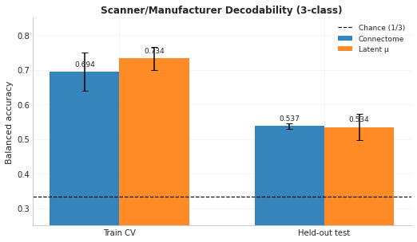

**Interpretation.** Held-out balanced accuracy is 0.537 for connectome features and 0.534 for latent μ (chance = 0.333). Scanner/manufacturer information is reduced but still decodable, so LOSO is methodologically necessary.

```python
if scanner_leakage_agg is None or scanner_leakage_agg.empty:
    warnings.warn("scanner_leakage_aggregate.csv not found; skipping scanner leakage section.")
else:
    display(scanner_leakage_agg)

    order_repr = ["connectome_norm", "latent_mu"]
    order_ctx = ["train_cv", "test_held"]
    repr_labels = {
        "connectome_norm": "Connectome",
        "latent_mu": "Latent μ",
    }
    ctx_labels = {
        "train_cv": "Train CV",
        "test_held": "Held-out test",
    }

    fig, ax = plt.subplots(figsize=(8.5, 4.8))
    x = np.arange(len(order_ctx))
    width = 0.34

    for i, rep in enumerate(order_repr):
        vals = []
        errs = []
        for ctx in order_ctx:
            row = scanner_leakage_agg[
                (scanner_leakage_agg["representation"] == rep)
                & (scanner_leakage_agg["context"] == ctx)
            ]
            if row.empty:
                vals.append(np.nan)
                errs.append(0.0)
            else:
                vals.append(float(row.iloc[0]["mean_bacc"]))
                errs.append(float(row.iloc[0]["std_bacc"]) if pd.notna(row.iloc[0]["std_bacc"]) else 0.0)
        xpos = x + (i - 0.5) * width
        color = COLORS["logreg"] if rep == "connectome_norm" else COLORS["svm"]
        bars = ax.bar(xpos, vals, width=width, color=color, alpha=0.9, label=repr_labels[rep], yerr=errs, capsize=4)
        for b, v in zip(bars, vals):
            if pd.notna(v):
                ax.text(b.get_x() + b.get_width() / 2, v + 0.012, f"{v:.3f}", ha="center", va="bottom", fontsize=9)

    ax.axhline(1/3, color="black", linestyle="--", linewidth=1.2, label="Chance (1/3)")
    ax.set_xticks(x)
    ax.set_xticklabels([ctx_labels[c] for c in order_ctx])
    ax.set_ylim(0.25, 0.85)
    ax.set_ylabel("Balanced accuracy")
    ax.set_title("Scanner/Manufacturer Decodability (3-class)")
    ax.legend(frameon=False)

    export_figure(fig, FIG_DIR, "04_scanner_leakage_context")
    plt.show()

    leak_summary = scanner_leakage_agg.copy()
    leak_summary["delta_vs_chance"] = leak_summary["mean_bacc"] - (1.0 / 3.0)
    leak_summary.to_csv(TABLE_DIR / "04_scanner_leakage_summary_table.csv", index=False)

    held = leak_summary[leak_summary["context"] == "test_held"].set_index("representation")
    if set(order_repr).issubset(held.index):
        display(Markdown(
            f"**Interpretation.** Held-out balanced accuracy is {held.loc['connectome_norm', 'mean_bacc']:.3f} for connectome features and "
            f"{held.loc['latent_mu', 'mean_bacc']:.3f} for latent μ (chance = 0.333). Scanner/manufacturer information is reduced but still decodable, so LOSO is methodologically necessary."
        ))
```

## 5. Main LOSO Performance (Primary Analysis: Logistic Regression)

This is the headline performance section for the revision.

|  | site | n_test | n_CN_test | n_AD_test | auc_final | pr_auc_final | balanced_accuracy | brier_final | sensitivity | specificity |
| --- | --- | --- | --- | --- | --- | --- | --- | --- | --- | --- |
| 0 | site_006 | 14 | 9 | 5 | 0.666667 | 0.588889 | 0.600000 | 0.222439 | 0.200000 | 1.00 |
| 1 | site_018 | 10 | 6 | 4 | 0.875000 | 0.854167 | 0.625000 | 0.193097 | 0.250000 | 1.00 |
| 2 | site_019 | 12 | 4 | 8 | 0.656250 | 0.853869 | 0.625000 | 0.304780 | 0.250000 | 1.00 |
| 3 | site_130 | 33 | 20 | 13 | 0.738462 | 0.628648 | 0.667308 | 0.204540 | 0.384615 | 0.95 |
| 4 | site_305 | 7 | 4 | 3 | 0.250000 | 0.383333 | 0.500000 | 0.297835 | 0.000000 | 1.00 |

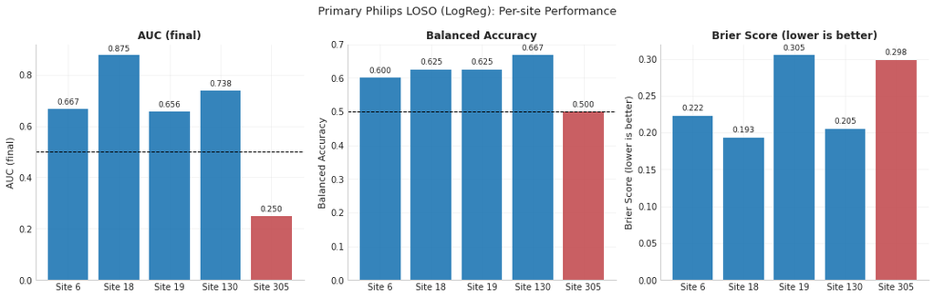

**Per-site mean ± SD:** AUC=0.637±0.233, balanced accuracy=0.603±0.063.  
**Top AUC sites:** Site 18, Site 130.  
**Pooled logreg:** AUC=0.681, PR-AUC=0.634, balanced accuracy=0.625, Brier=0.231, n=76.

**Outlier note (Site 305).** AUC=0.250, balanced accuracy=0.500, n=7 (CN=4, AD=3).

```python
if loso_primary_metrics is None or loso_primary_metrics.empty:
    raise RuntimeError("Missing primary LOSO site metrics.")

primary_site = loso_primary_metrics.copy()
if "classifier_type" in primary_site.columns:
    primary_site = primary_site[primary_site["classifier_type"] == "logreg"].copy()

primary_site["site_num"] = parse_site_series(primary_site["site"])
primary_site["site_order"] = primary_site["site_num"].map({s: i for i, s in enumerate(SITE_ORDER_PRIMARY)})
primary_site = primary_site.sort_values("site_order")

display(primary_site[[
    "site", "n_test", "n_CN_test", "n_AD_test", "auc_final", "pr_auc_final", "balanced_accuracy", "brier_final", "sensitivity", "specificity"
]].reset_index(drop=True))

primary_site.to_csv(TABLE_DIR / "05_primary_loso_site_metrics_table.csv", index=False)

fig, axes = plt.subplots(1, 3, figsize=(15, 4.8))
metrics_cfg = [
    ("auc_final", "AUC (final)", 0.5, True),
    ("balanced_accuracy", "Balanced Accuracy", 0.5, True),
    ("brier_final", "Brier Score (lower is better)", None, False),
]

x = np.arange(len(primary_site))
site_labels = [f"Site {int(s)}" for s in primary_site["site_num"]]
bar_colors = [COLORS["site305"] if int(s) == FAIL_SITE else COLORS["logreg"] for s in primary_site["site_num"]]

for ax, (metric, ylabel, ref, higher_better) in zip(axes, metrics_cfg):
    vals = primary_site[metric].values
    bars = ax.bar(x, vals, color=bar_colors, alpha=0.9)
    if ref is not None:
        ax.axhline(ref, color="black", linestyle="--", linewidth=1.0)
    for b, v in zip(bars, vals):
        ax.text(b.get_x() + b.get_width() / 2, v + (0.01 if higher_better else 0.005), f"{v:.3f}", ha="center", va="bottom", fontsize=9)
    ax.set_xticks(x)
    ax.set_xticklabels(site_labels, rotation=0)
    ax.set_ylabel(ylabel)
    ax.set_title(ylabel)

fig.suptitle("Primary Philips LOSO (LogReg): Per-site Performance", fontsize=13)
fig.tight_layout()
export_figure(fig, FIG_DIR, "05_primary_loso_triptych")
plt.show()

# Pooled callout + mean±SD
p_row = _extract_pooled(loso_primary_pooled, "logreg")
mean_auc = primary_site["auc_final"].mean()
sd_auc = primary_site["auc_final"].std(ddof=1)
mean_bal = primary_site["balanced_accuracy"].mean()
sd_bal = primary_site["balanced_accuracy"].std(ddof=1)

top_sites = primary_site.sort_values("auc_final", ascending=False).head(2)["site_num"].astype(int).tolist()

callout = (
    f"**Per-site mean ± SD:** AUC={mean_auc:.3f}±{sd_auc:.3f}, balanced accuracy={mean_bal:.3f}±{sd_bal:.3f}.  \n"
    f"**Top AUC sites:** {', '.join(f'Site {s}' for s in top_sites)}.  \n"
)
if p_row is not None:
    callout += (
        f"**Pooled logreg:** AUC={p_row['pooled_auc_final']:.3f}, PR-AUC={p_row['pooled_pr_auc_final']:.3f}, "
        f"balanced accuracy={p_row['pooled_balanced_accuracy']:.3f}, Brier={p_row['pooled_brier_final']:.3f}, n={int(p_row['n_total'])}."
    )
display(Markdown(callout))

# Explicitly show outlier site
outlier_row = primary_site[primary_site["site_num"] == FAIL_SITE]
if not outlier_row.empty:
    r = outlier_row.iloc[0]
    display(Markdown(
        f"**Outlier note (Site {FAIL_SITE}).** AUC={r['auc_final']:.3f}, balanced accuracy={r['balanced_accuracy']:.3f}, "
        f"n={int(r['n_test'])} (CN={int(r['n_CN_test'])}, AD={int(r['n_AD_test'])})."
    ))
```

|  | auc | ci_low | ci_high | n_boot |
| --- | --- | --- | --- | --- |
| 0 | 0.68258 | 0.553922 | 0.802102 | 2000 |

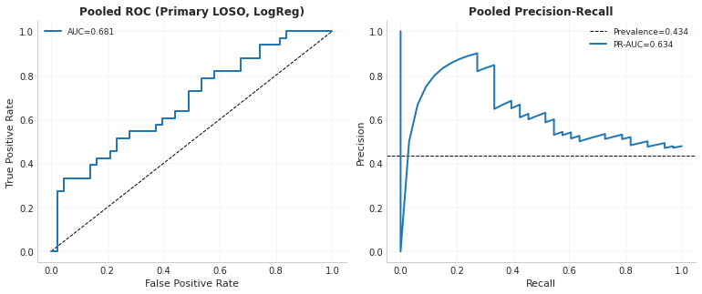

```python
# Optional pooled ROC/PR plots + bootstrap CI (from saved predictions only)
if loso_primary_preds is not None and not loso_primary_preds.empty:
    from sklearn.metrics import roc_curve, auc, precision_recall_curve, average_precision_score, roc_auc_score

    pp = loso_primary_preds.copy()
    if "classifier_type" in pp.columns:
        pp = pp[pp["classifier_type"] == "logreg"].copy()

    y_true = pp["y_true"].values.astype(int)
    y_score = pp["y_score_final"].values.astype(float)

    fpr, tpr, _ = roc_curve(y_true, y_score)
    precision, recall, _ = precision_recall_curve(y_true, y_score)
    roc_auc = roc_auc_score(y_true, y_score)
    pr_auc = average_precision_score(y_true, y_score)

    boot = bootstrap_auc_ci(y_true, y_score, n_boot=2000, seed=42)
    boot_df = pd.DataFrame([boot])
    boot_df.to_csv(TABLE_DIR / "05_primary_pooled_auc_bootstrap_ci.csv", index=False)
    display(boot_df)

    fig, axes = plt.subplots(1, 2, figsize=(10.8, 4.6))

    axes[0].plot([0, 1], [0, 1], linestyle="--", color="black", linewidth=1)
    axes[0].plot(fpr, tpr, color=COLORS["logreg"], linewidth=2, label=f"AUC={roc_auc:.3f}")
    axes[0].set_xlabel("False Positive Rate")
    axes[0].set_ylabel("True Positive Rate")
    axes[0].set_title("Pooled ROC (Primary LOSO, LogReg)")
    axes[0].legend(frameon=False)

    baseline = y_true.mean()
    axes[1].axhline(baseline, linestyle="--", color="black", linewidth=1, label=f"Prevalence={baseline:.3f}")
    axes[1].plot(recall, precision, color=COLORS["logreg"], linewidth=2, label=f"PR-AUC={pr_auc:.3f}")
    axes[1].set_xlabel("Recall")
    axes[1].set_ylabel("Precision")
    axes[1].set_title("Pooled Precision-Recall")
    axes[1].legend(frameon=False)

    fig.tight_layout()
    export_figure(fig, FIG_DIR, "05_primary_pooled_roc_pr")
    plt.show()
```

## 6. Strict LOSO Comparison

Strict LOSO (sites 6 and 130 only) is a complementary robustness check, not the main headline analysis.

|  | site_num | auc_final_primary | balanced_accuracy_primary | brier_final_primary | auc_final_strict | balanced_accuracy_strict | brier_final_strict | delta_auc_strict_minus_primary | delta_balacc_strict_minus_primary |
| --- | --- | --- | --- | --- | --- | --- | --- | --- | --- |
| 0 | 6 | 0.666667 | 0.600000 | 0.222439 | 0.666667 | 0.600000 | 0.222429 | 0.000000 | 0.000000 |
| 1 | 130 | 0.738462 | 0.667308 | 0.204540 | 0.696154 | 0.538462 | 0.220711 | -0.042308 | -0.128846 |

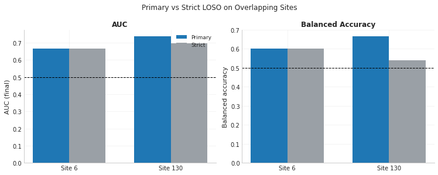

**Interpretation.** Site 130 changes from AUC=0.738 (primary) to 0.696 (strict); the direction and magnitude are modest, supporting strict LOSO as complementary rather than contradictory.

```python
if loso_strict_metrics is None or loso_strict_metrics.empty:
    warnings.warn("Strict LOSO metrics not found; skipping strict comparison.")
else:
    strict_site = loso_strict_metrics.copy()
    if "classifier_type" in strict_site.columns:
        strict_site = strict_site[strict_site["classifier_type"] == "logreg"].copy()
    strict_site["site_num"] = parse_site_series(strict_site["site"])

    comp = primary_site[["site_num", "auc_final", "balanced_accuracy", "brier_final"]].merge(
        strict_site[["site_num", "auc_final", "balanced_accuracy", "brier_final"]],
        on="site_num",
        how="inner",
        suffixes=("_primary", "_strict"),
    )
    comp = comp.sort_values("site_num")
    comp["delta_auc_strict_minus_primary"] = comp["auc_final_strict"] - comp["auc_final_primary"]
    comp["delta_balacc_strict_minus_primary"] = comp["balanced_accuracy_strict"] - comp["balanced_accuracy_primary"]
    comp.to_csv(TABLE_DIR / "06_strict_vs_primary_overlap.csv", index=False)
    display(comp)

    fig, axes = plt.subplots(1, 2, figsize=(10.5, 4.2))
    x = np.arange(len(comp))
    w = 0.36

    axes[0].bar(x - w / 2, comp["auc_final_primary"], width=w, color=COLORS["logreg"], label="Primary")
    axes[0].bar(x + w / 2, comp["auc_final_strict"], width=w, color=COLORS["neutral"], label="Strict")
    axes[0].axhline(0.5, linestyle="--", color="black", linewidth=1)
    axes[0].set_xticks(x)
    axes[0].set_xticklabels([f"Site {int(s)}" for s in comp["site_num"]])
    axes[0].set_ylabel("AUC (final)")
    axes[0].set_title("AUC")
    axes[0].legend(frameon=False)

    axes[1].bar(x - w / 2, comp["balanced_accuracy_primary"], width=w, color=COLORS["logreg"], label="Primary")
    axes[1].bar(x + w / 2, comp["balanced_accuracy_strict"], width=w, color=COLORS["neutral"], label="Strict")
    axes[1].axhline(0.5, linestyle="--", color="black", linewidth=1)
    axes[1].set_xticks(x)
    axes[1].set_xticklabels([f"Site {int(s)}" for s in comp["site_num"]])
    axes[1].set_ylabel("Balanced accuracy")
    axes[1].set_title("Balanced Accuracy")

    fig.suptitle("Primary vs Strict LOSO on Overlapping Sites")
    fig.tight_layout()
    export_figure(fig, FIG_DIR, "06_primary_vs_strict_overlap")
    plt.show()

    if not comp.empty:
        row130 = comp[comp["site_num"] == 130]
        if not row130.empty:
            r130 = row130.iloc[0]
            display(Markdown(
                f"**Interpretation.** Site 130 changes from AUC={r130['auc_final_primary']:.3f} (primary) to {r130['auc_final_strict']:.3f} (strict); "
                f"the direction and magnitude are modest, supporting strict LOSO as complementary rather than contradictory."
            ))
```

## 7. LogReg vs SVM Sensitivity Analysis

SVM is treated as a secondary sensitivity analysis; logistic regression remains the headline model.

| classifier_type | site_num | logreg_auc | svm_auc | logreg_balacc | svm_balacc |
| --- | --- | --- | --- | --- | --- |
| 0 | 6 | 0.666667 | 0.733333 | 0.600000 | 0.500000 |
| 1 | 18 | 0.875000 | 0.750000 | 0.625000 | 0.500000 |
| 2 | 19 | 0.656250 | 0.687500 | 0.625000 | 0.625000 |
| 3 | 130 | 0.738462 | 0.665385 | 0.667308 | 0.667308 |
| 4 | 305 | 0.250000 | 0.250000 | 0.500000 | 0.500000 |

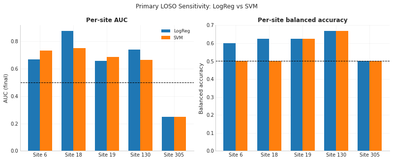

|  | classifier | pooled_auc_final | pooled_balanced_accuracy | pooled_brier_final |
| --- | --- | --- | --- | --- |
| 0 | logreg | 0.681466 | 0.624736 | 0.230713 |
| 1 | svm | 0.635659 | 0.589852 | 0.240906 |

**Interpretation.** SVM does not change the main conclusion: pooled AUC is 0.636 for SVM versus 0.681 for logreg, and pooled balanced accuracy is also lower for SVM. LogReg remains preferable for the revision narrative (performance plus interpretability).

```python
if loso_primary_svm_metrics is None or loso_primary_svm_metrics.empty:
    warnings.warn("Primary+SVM metrics not found; skipping classifier sensitivity section.")
else:
    svm_cmp = loso_primary_svm_metrics.copy()
    svm_cmp["site_num"] = parse_site_series(svm_cmp["site"])
    svm_cmp = svm_cmp[svm_cmp["site_num"].isin(SITE_ORDER_PRIMARY)].copy()

    pivot_auc = svm_cmp.pivot_table(index="site_num", columns="classifier_type", values="auc_final", aggfunc="first")
    pivot_bal = svm_cmp.pivot_table(index="site_num", columns="classifier_type", values="balanced_accuracy", aggfunc="first")

    compare_tbl = pivot_auc.join(pivot_bal, lsuffix="_auc", rsuffix="_balacc").reset_index().sort_values("site_num")
    compare_tbl.to_csv(TABLE_DIR / "07_logreg_vs_svm_per_site.csv", index=False)
    display(compare_tbl)

    fig, axes = plt.subplots(1, 2, figsize=(11.2, 4.6))
    x = np.arange(len(compare_tbl))
    w = 0.36

    if "logreg_auc" in compare_tbl.columns:
        axes[0].bar(x - w / 2, compare_tbl["logreg_auc"], width=w, color=COLORS["logreg"], label="LogReg")
    if "svm_auc" in compare_tbl.columns:
        axes[0].bar(x + w / 2, compare_tbl["svm_auc"], width=w, color=COLORS["svm"], label="SVM")
    axes[0].axhline(0.5, linestyle="--", color="black", linewidth=1)
    axes[0].set_xticks(x)
    axes[0].set_xticklabels([f"Site {int(s)}" for s in compare_tbl["site_num"]])
    axes[0].set_ylabel("AUC (final)")
    axes[0].set_title("Per-site AUC")
    axes[0].legend(frameon=False)

    if "logreg_balacc" in compare_tbl.columns:
        axes[1].bar(x - w / 2, compare_tbl["logreg_balacc"], width=w, color=COLORS["logreg"], label="LogReg")
    if "svm_balacc" in compare_tbl.columns:
        axes[1].bar(x + w / 2, compare_tbl["svm_balacc"], width=w, color=COLORS["svm"], label="SVM")
    axes[1].axhline(0.5, linestyle="--", color="black", linewidth=1)
    axes[1].set_xticks(x)
    axes[1].set_xticklabels([f"Site {int(s)}" for s in compare_tbl["site_num"]])
    axes[1].set_ylabel("Balanced accuracy")
    axes[1].set_title("Per-site balanced accuracy")

    fig.suptitle("Primary LOSO Sensitivity: LogReg vs SVM")
    fig.tight_layout()
    export_figure(fig, FIG_DIR, "07_logreg_vs_svm_per_site")
    plt.show()

    pooled_svm = _extract_pooled(loso_primary_svm_pooled, "svm")
    pooled_log = _extract_pooled(loso_primary_svm_pooled, "logreg")
    if pooled_svm is not None and pooled_log is not None:
        pooled_cmp = pd.DataFrame([
            {
                "classifier": "logreg",
                "pooled_auc_final": pooled_log.get("pooled_auc_final", np.nan),
                "pooled_balanced_accuracy": pooled_log.get("pooled_balanced_accuracy", np.nan),
                "pooled_brier_final": pooled_log.get("pooled_brier_final", np.nan),
            },
            {
                "classifier": "svm",
                "pooled_auc_final": pooled_svm.get("pooled_auc_final", np.nan),
                "pooled_balanced_accuracy": pooled_svm.get("pooled_balanced_accuracy", np.nan),
                "pooled_brier_final": pooled_svm.get("pooled_brier_final", np.nan),
            },
        ])
        pooled_cmp.to_csv(TABLE_DIR / "07_logreg_vs_svm_pooled.csv", index=False)
        display(pooled_cmp)

        display(Markdown(
            f"**Interpretation.** SVM does not change the main conclusion: pooled AUC is {pooled_svm.get('pooled_auc_final', np.nan):.3f} for SVM versus "
            f"{pooled_log.get('pooled_auc_final', np.nan):.3f} for logreg, and pooled balanced accuracy is also lower for SVM. "
            "LogReg remains preferable for the revision narrative (performance plus interpretability)."
        ))
```

## 8. Calibration Analysis (Reviewer #1)

We evaluate pooled calibration for the primary LOSO logreg model using saved calibration bins and subject-level probabilities.

|  | calibration_slope | calibration_intercept | ece_10bins | n |
| --- | --- | --- | --- | --- |
| 0 | 1.040923 | 0.488171 | 0.142725 | 76 |

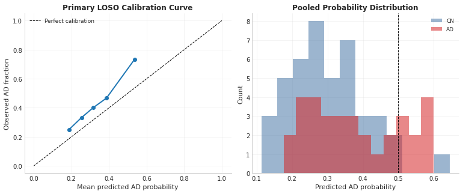

**Interpretation.** Calibration slope=1.041, intercept=0.488, ECE=0.143. This supports a direct response to Reviewer #1 by quantifying whether pooled probabilities are over- or under-confident.

```python
if loso_primary_preds is None or loso_primary_preds.empty:
    warnings.warn("Primary predictions missing; calibration analysis is limited.")
else:
    from sklearn.calibration import calibration_curve

    pp = loso_primary_preds.copy()
    if "classifier_type" in pp.columns:
        pp = pp[pp["classifier_type"] == "logreg"].copy()
    y_true = pp["y_true"].values.astype(int)
    y_prob = pp["y_score_final"].values.astype(float)

    cal_df = loso_primary_cal_curve
    if cal_df is None or cal_df.empty:
        frac_pos, mean_pred = calibration_curve(y_true, y_prob, n_bins=5, strategy="quantile")
        cal_df = pd.DataFrame({"mean_pred_prob": mean_pred, "frac_pos": frac_pos})

    slope_int = calibration_slope_intercept(y_true, y_prob)
    ece = expected_calibration_error(y_true, y_prob, n_bins=10)

    cal_stats = pd.DataFrame([
        {
            "calibration_slope": slope_int["slope"],
            "calibration_intercept": slope_int["intercept"],
            "ece_10bins": ece,
            "n": len(y_true),
        }
    ])
    cal_stats.to_csv(TABLE_DIR / "08_primary_calibration_stats.csv", index=False)
    display(cal_stats)

    fig, axes = plt.subplots(1, 2, figsize=(10.8, 4.6))

    axes[0].plot([0, 1], [0, 1], linestyle="--", color="black", linewidth=1, label="Perfect calibration")
    axes[0].plot(cal_df["mean_pred_prob"], cal_df["frac_pos"], marker="o", color=COLORS["logreg"], linewidth=2)
    axes[0].set_xlabel("Mean predicted AD probability")
    axes[0].set_ylabel("Observed AD fraction")
    axes[0].set_title("Primary LOSO Calibration Curve")
    axes[0].legend(frameon=False)

    for yv, lbl, col in [(0, "CN", COLORS["cn"]), (1, "AD", COLORS["ad"])]:
        vals = y_prob[y_true == yv]
        axes[1].hist(vals, bins=12, alpha=0.55, label=lbl, color=col)
    axes[1].axvline(0.5, color="black", linestyle="--", linewidth=1)
    axes[1].set_xlabel("Predicted AD probability")
    axes[1].set_ylabel("Count")
    axes[1].set_title("Pooled Probability Distribution")
    axes[1].legend(frameon=False)

    fig.tight_layout()
    export_figure(fig, FIG_DIR, "08_primary_calibration")
    plt.show()

    display(Markdown(
        f"**Interpretation.** Calibration slope={slope_int['slope']:.3f}, intercept={slope_int['intercept']:.3f}, ECE={ece:.3f}. "
        "This supports a direct response to Reviewer #1 by quantifying whether pooled probabilities are over- or under-confident."
    ))
```

## 9. Deep Dive on Site 305

Site 305 is the key outlier. We audit it across subject roster, clinical covariates, protocol context, and prediction behavior.

```python
if loso_primary_preds is None or loso_primary_preds.empty:
    raise RuntimeError("Primary predictions are required for the site 305 deep dive.")

philips_cn_ad = meta[
    meta["ResearchGroup_Mapped"].isin(["CN", "AD"]) & meta["Manufacturer"].astype(str).str.contains("Philips", case=False, na=False)
].copy()

site305_meta = philips_cn_ad[philips_cn_ad["Site3"] == FAIL_SITE].copy()
other_loso_meta = philips_cn_ad[
    philips_cn_ad["Site3"].isin(SITE_ORDER_PRIMARY) & (philips_cn_ad["Site3"] != FAIL_SITE)
].copy()

pred305 = loso_primary_preds.copy()
if "classifier_type" in pred305.columns:
    pred305 = pred305[pred305["classifier_type"] == "logreg"].copy()
pred305 = pred305[parse_site_series(pred305["site"]) == FAIL_SITE].copy()

roster_cols = ["SubjectID", "ResearchGroup_Mapped", "Age", "Sex", "MMSE", "CDRSB", "PTEDUCAT", "Phase", "Slice Thickness", "ImagingProtocol"]
roster305 = site305_meta[roster_cols].merge(
    pred305[["SubjectID", "y_score_final", "y_pred"]], on="SubjectID", how="left"
)
roster305 = roster305.sort_values(["ResearchGroup_Mapped", "Age"])

roster305.to_csv(TABLE_DIR / "09_site305_subject_roster_with_predictions.csv", index=False)
display(roster305)

display(Markdown(
    f"**Roster interpretation.** Site 305 contributes {len(site305_meta)} subjects (CN={int((site305_meta['ResearchGroup_Mapped'] == 'CN').sum())}, "
    f"AD={int((site305_meta['ResearchGroup_Mapped'] == 'AD').sum())}), so fold-level uncertainty is intrinsically high."
))
```

|  | SubjectID | ResearchGroup_Mapped | Age | Sex | MMSE | CDRSB | PTEDUCAT | Phase | Slice Thickness | ImagingProtocol | y_score_final | y_pred |
| --- | --- | --- | --- | --- | --- | --- | --- | --- | --- | --- | --- | --- |
| 6 | 305_S_6881 | AD | 62.0 | F | NaN | NaN | NaN | ADNI 3 | 3.4 | Field Strength=3.0;TE=30.0;Manufacturer=Philip... | 0.245489 | 0 |
| 4 | 305_S_6810 | AD | 73.2 | M | 22.0 | 4.5 | 16.0 | ADNI 3 | 3.4 | Field Strength=3.0;TE=30.0;Manufacturer=Philip... | 0.176250 | 0 |
| 5 | 305_S_6850 | AD | 79.8 | M | 24.0 | 4.0 | 19.0 | ADNI 3 | 3.4 | Field Strength=3.0;TE=30.0;Manufacturer=Philip... | 0.226391 | 0 |
| 2 | 305_S_6313 | CN | 59.1 | F | 30.0 | 0.0 | 20.0 | ADNI 3 | 3.4 | Field Strength=3.0;TE=30.0;Manufacturer=Philip... | 0.291954 | 0 |
| 1 | 305_S_6188 | CN | 65.6 | F | 30.0 | 0.0 | 18.0 | ADNI 3 | 3.4 | Field Strength=3.0;TE=30.0;Manufacturer=Philip... | 0.248087 | 0 |
| 0 | 305_S_6157 | CN | 67.8 | F | 29.0 | 0.0 | 12.0 | ADNI 3 | 3.4 | Field Strength=3.0;TE=30.0;Manufacturer=Philip... | 0.156335 | 0 |
| 3 | 305_S_6438 | CN | 71.7 | F | NaN | NaN | NaN | ADNI 3 | 3.4 | Field Strength=3.0;TE=30.0;Manufacturer=Philip... | 0.259415 | 0 |

**Roster interpretation.** Site 305 contributes 7 subjects (CN=4, AD=3), so fold-level uncertainty is intrinsically high.

|  | variable | site305_n | site305_mean | site305_std | other_n | other_mean | other_std |
| --- | --- | --- | --- | --- | --- | --- | --- |
| 0 | Age | 7 | 68.457143 | 7.065375 | 69 | 74.995652 | 7.094124 |
| 1 | MMSE | 5 | 27.000000 | 3.741657 | 51 | 25.882353 | 4.384733 |
| 2 | CDRSB | 5 | 1.700000 | 2.334524 | 50 | 1.830000 | 2.940932 |
| 3 | PTEDUCAT | 5 | 17.000000 | 3.162278 | 63 | 16.031746 | 2.627204 |

|  | variable | smd_site305_minus_other |
| --- | --- | --- |
| 0 | Age | -0.921982 |
| 1 | MMSE | 0.257501 |
| 2 | CDRSB | -0.044834 |
| 3 | PTEDUCAT | 0.363637 |

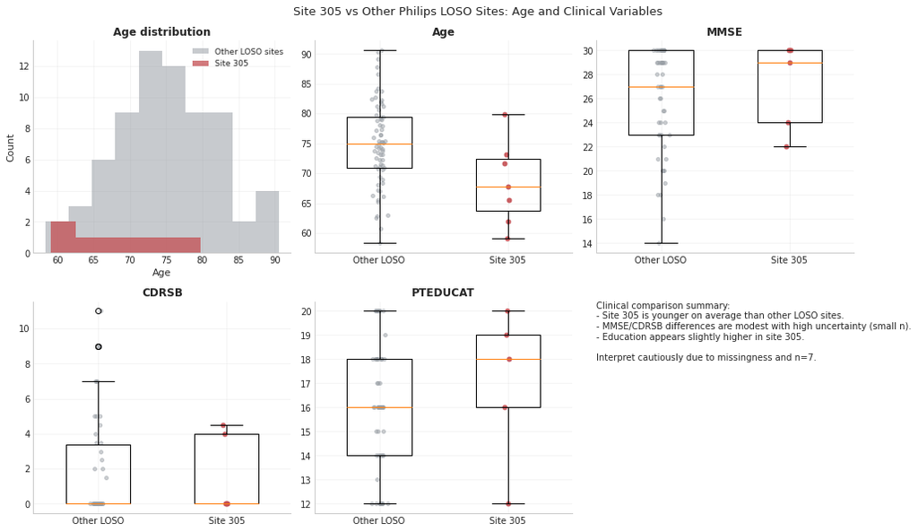

**Interpretation (Age/clinical).** Site 305 mean age is 68.5 vs 75.0 in other LOSO sites; this suggests cohort shift is plausible. Clinical score differences are smaller and should be interpreted as exploratory because of missing data and very small n.

```python
# 9.1 Age and clinical variable comparison
vars_key = ["Age", "MMSE", "CDRSB", "PTEDUCAT"]

summary_rows = []
smd_rows = []
for v in vars_key:
    a = pd.to_numeric(site305_meta[v], errors="coerce")
    b = pd.to_numeric(other_loso_meta[v], errors="coerce")
    summary_rows.append(
        {
            "variable": v,
            "site305_n": int(a.notna().sum()),
            "site305_mean": float(a.mean()),
            "site305_std": float(a.std(ddof=1)),
            "other_n": int(b.notna().sum()),
            "other_mean": float(b.mean()),
            "other_std": float(b.std(ddof=1)),
        }
    )
    smd_rows.append({"variable": v, "smd_site305_minus_other": standardized_mean_difference(a.dropna(), b.dropna())})

clinical_summary = pd.DataFrame(summary_rows)
clinical_smd = pd.DataFrame(smd_rows)
display(clinical_summary)
display(clinical_smd)

clinical_summary.to_csv(TABLE_DIR / "09_site305_clinical_summary.csv", index=False)
clinical_smd.to_csv(TABLE_DIR / "09_site305_clinical_smd.csv", index=False)

fig, axes = plt.subplots(2, 3, figsize=(15, 8.4))

# Age distribution panel
axes[0, 0].hist(pd.to_numeric(other_loso_meta["Age"], errors="coerce").dropna(), bins=10, alpha=0.55, color=COLORS["neutral"], label="Other LOSO sites")
axes[0, 0].hist(pd.to_numeric(site305_meta["Age"], errors="coerce").dropna(), bins=6, alpha=0.75, color=COLORS["site305"], label="Site 305")
axes[0, 0].set_title("Age distribution")
axes[0, 0].set_xlabel("Age")
axes[0, 0].set_ylabel("Count")
axes[0, 0].legend(frameon=False)

# Clinical box/strip panels
plot_positions = {
    "Age": (0, 1),
    "MMSE": (0, 2),
    "CDRSB": (1, 0),
    "PTEDUCAT": (1, 1),
}
for v, (r, c) in plot_positions.items():
    s305_vals = pd.to_numeric(site305_meta[v], errors="coerce").dropna().values
    other_vals = pd.to_numeric(other_loso_meta[v], errors="coerce").dropna().values
    axes[r, c].boxplot([other_vals, s305_vals], labels=["Other LOSO", "Site 305"], widths=0.5)
    if len(other_vals):
        jitter = np.random.default_rng(42).normal(0, 0.03, len(other_vals))
        axes[r, c].scatter(np.full(len(other_vals), 1) + jitter, other_vals, s=16, alpha=0.5, color=COLORS["neutral"])
    if len(s305_vals):
        jitter = np.random.default_rng(7).normal(0, 0.03, len(s305_vals))
        axes[r, c].scatter(np.full(len(s305_vals), 2) + jitter, s305_vals, s=24, alpha=0.9, color=COLORS["site305"])
    axes[r, c].set_title(v)

axes[1, 2].axis("off")
axes[1, 2].text(
    0,
    1,
    "Clinical comparison summary:\n"
    "- Site 305 is younger on average than other LOSO sites.\n"
    "- MMSE/CDRSB differences are modest with high uncertainty (small n).\n"
    "- Education appears slightly higher in site 305.\n"
    "\nInterpret cautiously due to missingness and n=7.",
    va="top",
    fontsize=10,
)

fig.suptitle("Site 305 vs Other Philips LOSO Sites: Age and Clinical Variables", fontsize=13)
fig.tight_layout()
export_figure(fig, FIG_DIR, "09_site305_age_clinical_audit")
plt.show()

age_row = clinical_summary[clinical_summary["variable"] == "Age"].iloc[0]
display(Markdown(
    f"**Interpretation (Age/clinical).** Site 305 mean age is {age_row['site305_mean']:.1f} vs {age_row['other_mean']:.1f} in other LOSO sites; "
    "this suggests cohort shift is plausible. Clinical score differences are smaller and should be interpreted as exploratory because of missing data and very small n."
))
```

| Sex group | F | M |
| --- | --- | --- |
| Other LOSO sites | 38 | 31 |
| Site 305 | 5 | 2 |

| Phase group | ADNI 2 | ADNI 3 |
| --- | --- | --- |
| Other LOSO sites | 37 | 32 |
| Site 305 | 0 | 7 |

| Slice Thickness group | 3.3 | 3.4 |
| --- | --- | --- |
| Other LOSO sites | 37 | 32 |
| Site 305 | 0 | 7 |

|  | group | ImagingProtocol | n |
| --- | --- | --- | --- |
| 0 | Other LOSO sites | Field Strength=3.0;TE=30.0;Manufacturer=Philip... | 37 |
| 1 | Other LOSO sites | Field Strength=3.0;TE=30.0;Manufacturer=Philip... | 32 |
| 2 | Site 305 | Field Strength=3.0;TE=30.0;Manufacturer=Philip... | 7 |

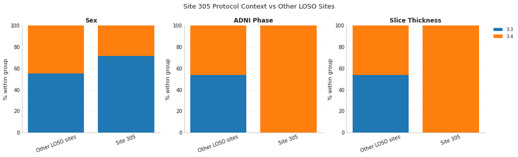

**Interpretation (protocol context).** Site 305 subjects are all from ADNI 3 and share a single slice-thickness setting, while comparator sites include mixed ADNI phases and scanner settings. This supports a plausible protocol/phase shift contribution to fold-specific degradation.

```python
# 9.2 Sex / phase / slice thickness / protocol context
site_label = np.where(philips_cn_ad["Site3"] == FAIL_SITE, "Site 305", "Other LOSO sites")
context_df = philips_cn_ad[philips_cn_ad["Site3"].isin(SITE_ORDER_PRIMARY)].copy()
context_df["group"] = np.where(context_df["Site3"] == FAIL_SITE, "Site 305", "Other LOSO sites")

sex_tab = pd.crosstab(context_df["group"], context_df["Sex"])
phase_tab = pd.crosstab(context_df["group"], context_df["Phase"])
slice_tab = pd.crosstab(context_df["group"], context_df["Slice Thickness"])

protocol_counts = (
    context_df.groupby(["group", "ImagingProtocol"]).size().reset_index(name="n")
    .sort_values(["group", "n"], ascending=[True, False])
)

sex_tab.to_csv(TABLE_DIR / "09_site305_vs_other_sex_table.csv")
phase_tab.to_csv(TABLE_DIR / "09_site305_vs_other_phase_table.csv")
slice_tab.to_csv(TABLE_DIR / "09_site305_vs_other_slice_table.csv")
protocol_counts.to_csv(TABLE_DIR / "09_site305_vs_other_protocol_counts.csv", index=False)

display(sex_tab)
display(phase_tab)
display(slice_tab)
display(protocol_counts.head(10))

fig, axes = plt.subplots(1, 3, figsize=(14.5, 4.4))

for ax, tab, title in zip(
    axes,
    [sex_tab, phase_tab, slice_tab],
    ["Sex", "ADNI Phase", "Slice Thickness"],
):
    tab_pct = tab.div(tab.sum(axis=1), axis=0) * 100
    bottom = np.zeros(len(tab_pct))
    for col in tab_pct.columns:
        vals = tab_pct[col].values
        ax.bar(tab_pct.index, vals, bottom=bottom, label=str(col))
        bottom = bottom + vals
    ax.set_ylim(0, 100)
    ax.set_ylabel("% within group")
    ax.set_title(title)
    ax.tick_params(axis="x", rotation=20)

axes[-1].legend(frameon=False, bbox_to_anchor=(1.03, 1.02), loc="upper left")
fig.suptitle("Site 305 Protocol Context vs Other LOSO Sites", fontsize=13)
fig.tight_layout()
export_figure(fig, FIG_DIR, "09_site305_protocol_context")
plt.show()

display(Markdown(
    "**Interpretation (protocol context).** Site 305 subjects are all from ADNI 3 and share a single slice-thickness setting, while comparator sites include mixed ADNI phases and scanner settings. "
    "This supports a plausible protocol/phase shift contribution to fold-specific degradation."
))
```

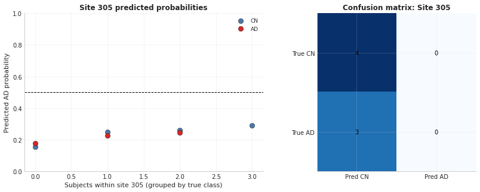

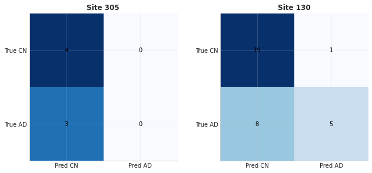

**Interpretation (prediction behavior).** Site 305 has AUC=0.250 and balanced accuracy=0.500; confusion matrix TN=4, FP=0, FN=3, TP=0. All predictions are negative at threshold 0.5. Mean predicted AD probability is 0.216 for true AD vs 0.239 for true CN. Therefore, the degradation is not only a threshold issue (all probabilities below 0.5) but also a ranking issue (AUC below 0.5).

```python
# 9.3 Prediction probabilities and threshold-vs-ranking diagnosis
from sklearn.metrics import confusion_matrix, roc_auc_score, balanced_accuracy_score

pred_main = loso_primary_preds.copy()
if "classifier_type" in pred_main.columns:
    pred_main = pred_main[pred_main["classifier_type"] == "logreg"].copy()
pred_main["site_num"] = parse_site_series(pred_main["site"])

p305 = pred_main[pred_main["site_num"] == FAIL_SITE].copy()
p130 = pred_main[pred_main["site_num"] == 130].copy()

# Probability scatter for site 305
fig, axes = plt.subplots(1, 2, figsize=(12.2, 4.6))

if not p305.empty:
    p305 = p305.sort_values(["y_true", "y_score_final"]).reset_index(drop=True)
    for yv, lbl, col in [(0, "CN", COLORS["cn"]), (1, "AD", COLORS["ad"])]:
        sub = p305[p305["y_true"] == yv]
        axes[0].scatter(
            np.arange(len(sub)),
            sub["y_score_final"],
            s=70,
            color=col,
            edgecolor="black",
            linewidth=0.4,
            label=lbl,
        )
    axes[0].axhline(0.5, linestyle="--", color="black", linewidth=1)
    axes[0].set_ylim(0, 1)
    axes[0].set_xlabel("Subjects within site 305 (grouped by true class)")
    axes[0].set_ylabel("Predicted AD probability")
    axes[0].set_title("Site 305 predicted probabilities")
    axes[0].legend(frameon=False)

# Confusion matrices for site 305 vs site 130
def _plot_cm(ax, df, title):
    if df.empty:
        ax.axis("off")
        ax.set_title(title + " (missing)")
        return
    cm = confusion_matrix(df["y_true"], df["y_pred"], labels=[0, 1])
    im = ax.imshow(cm, cmap="Blues")
    for i in range(cm.shape[0]):
        for j in range(cm.shape[1]):
            ax.text(j, i, str(cm[i, j]), ha="center", va="center", color="black")
    ax.set_xticks([0, 1]); ax.set_yticks([0, 1])
    ax.set_xticklabels(["Pred CN", "Pred AD"])
    ax.set_yticklabels(["True CN", "True AD"])
    ax.set_title(title)

_plot_cm(axes[1], p305, "Confusion matrix: Site 305")
fig.tight_layout()
export_figure(fig, FIG_DIR, "09_site305_prediction_behavior")
plt.show()

# Additional CM figure including site 130 reference
fig, ax_arr = plt.subplots(1, 2, figsize=(9.2, 4.2))
_plot_cm(ax_arr[0], p305, "Site 305")
_plot_cm(ax_arr[1], p130, "Site 130")
fig.tight_layout()
export_figure(fig, FIG_DIR, "09_site305_vs_site130_confusion")
plt.show()

if not p305.empty:
    auc305 = roc_auc_score(p305["y_true"], p305["y_score_final"])
    bal305 = balanced_accuracy_score(p305["y_true"], p305["y_pred"])
    tn, fp, fn, tp = confusion_matrix(p305["y_true"], p305["y_pred"], labels=[0, 1]).ravel()

    all_pred_negative = int((p305["y_pred"] == 0).all())
    mean_cn = p305.loc[p305["y_true"] == 0, "y_score_final"].mean()
    mean_ad = p305.loc[p305["y_true"] == 1, "y_score_final"].mean()

    msg = (
        f"**Interpretation (prediction behavior).** Site 305 has AUC={auc305:.3f} and balanced accuracy={bal305:.3f}; confusion matrix TN={tn}, FP={fp}, FN={fn}, TP={tp}. "
        f"All predictions are {'negative' if all_pred_negative else 'not all negative'} at threshold 0.5. "
        f"Mean predicted AD probability is {mean_ad:.3f} for true AD vs {mean_cn:.3f} for true CN. "
        "Therefore, the degradation is not only a threshold issue (all probabilities below 0.5) but also a ranking issue (AUC below 0.5)."
    )
    display(Markdown(msg))
```

## 10. Connectome-Space Audit of Site 305

This exploratory geometry analysis projects Philips LOSO subjects into a PCA space of vectorized connectomes (channels `[1, 0, 2]`) and examines centroid distances and nearest-neighbor proximity.

Caution: PCA is descriptive/exploratory and not a causal proof of site effects.

```
PCA explained variance: PC1=0.086, PC2=0.041
```

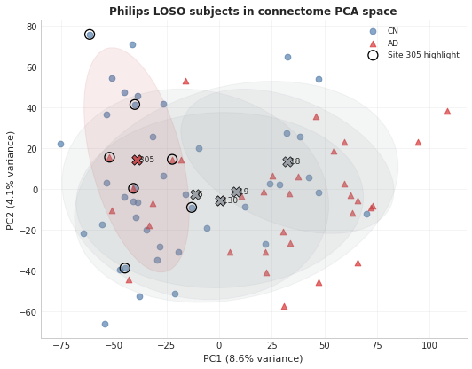

|  | Site3 | PC1 | PC2 | distance_to_global_train_centroid |
| --- | --- | --- | --- | --- |
| 4 | 305 | -39.216255 | 14.230805 | 45.950775 |
| 1 | 18 | 32.454445 | 13.531430 | 32.173534 |
| 0 | 6 | -11.291041 | -2.606050 | 15.313678 |
| 3 | 130 | 0.307749 | -5.490703 | 5.463727 |
| 2 | 19 | 8.157350 | -1.437666 | 4.178894 |

| group | count | mean | std | min | 25% | 50% | 75% | max |
| --- | --- | --- | --- | --- | --- | --- | --- | --- |
| rest_to_rest | 69.0 | 186.493698 | 10.990723 | 164.990128 | 177.499252 | 187.583176 | 191.033615 | 221.493500 |
| site305_to_rest | 7.0 | 185.618576 | 5.738574 | 175.886337 | 183.024910 | 186.410873 | 189.450874 | 192.081284 |

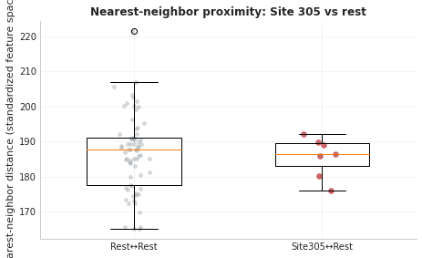

```python
from sklearn.decomposition import PCA
from sklearn.preprocessing import StandardScaler
from sklearn.metrics import pairwise_distances

tensor_subject_map = pd.DataFrame({
    "SubjectID": tensor_subject_ids,
    "tensor_idx_from_npz": np.arange(len(tensor_subject_ids), dtype=int),
})

philips_loso = philips_cn_ad[philips_cn_ad["Site3"].isin(SITE_ORDER_PRIMARY)].copy()
philips_loso_tensor = philips_loso.merge(tensor_subject_map, on="SubjectID", how="inner").copy()

tri = np.triu_indices(global_tensor.shape[-1], k=1)

def _vectorize_subject(idx: int, channels: list):
    mats = global_tensor[idx, channels, :, :]
    return np.concatenate([m[tri] for m in mats], axis=0)

X = np.vstack([
    _vectorize_subject(int(idx), CHANNELS_TO_USE)
    for idx in philips_loso_tensor["tensor_idx_from_npz"].values
])

scaler = StandardScaler()
X_scaled = scaler.fit_transform(X)

pca = PCA(n_components=2, random_state=42)
X_pca = pca.fit_transform(X_scaled)

philips_loso_tensor["PC1"] = X_pca[:, 0]
philips_loso_tensor["PC2"] = X_pca[:, 1]

explained = pca.explained_variance_ratio_
print(f"PCA explained variance: PC1={explained[0]:.3f}, PC2={explained[1]:.3f}")

def _add_confidence_ellipse(ax, x, y, color, n_std=1.5, alpha=0.12):
    if len(x) < 3:
        return
    cov = np.cov(x, y)
    vals, vecs = np.linalg.eigh(cov)
    order = vals.argsort()[::-1]
    vals, vecs = vals[order], vecs[:, order]
    angle = np.degrees(np.arctan2(*vecs[:, 0][::-1]))
    width, height = 2 * n_std * np.sqrt(np.maximum(vals, 1e-12))
    ell = Ellipse((np.mean(x), np.mean(y)), width, height, angle=angle, facecolor=color, edgecolor=color, lw=1.0, alpha=alpha)
    ax.add_patch(ell)

fig, ax = plt.subplots(figsize=(8.6, 6.6))

for cls, col, marker in [("CN", COLORS["cn"], "o"), ("AD", COLORS["ad"], "^")]:
    sub = philips_loso_tensor[philips_loso_tensor["ResearchGroup_Mapped"] == cls]
    ax.scatter(sub["PC1"], sub["PC2"], c=col, s=45, marker=marker, alpha=0.65, label=cls)

# Site-level ellipses and centroids
centroids = (
    philips_loso_tensor.groupby("Site3")[["PC1", "PC2"]].mean().reset_index().sort_values("Site3")
)
for _, row in centroids.iterrows():
    s = int(row["Site3"])
    ss = philips_loso_tensor[philips_loso_tensor["Site3"] == s]
    color = COLORS["site305"] if s == FAIL_SITE else COLORS["neutral"]
    _add_confidence_ellipse(ax, ss["PC1"].values, ss["PC2"].values, color=color, n_std=1.5, alpha=0.10)
    ax.scatter(row["PC1"], row["PC2"], marker="X", s=130, c=color, edgecolor="black", linewidth=0.8)
    ax.text(row["PC1"], row["PC2"], f" {s}", fontsize=9, va="center")

sub_fail = philips_loso_tensor[philips_loso_tensor["Site3"] == FAIL_SITE]
ax.scatter(
    sub_fail["PC1"],
    sub_fail["PC2"],
    facecolors="none",
    edgecolors="black",
    linewidths=1.3,
    s=120,
    label=f"Site {FAIL_SITE} highlight",
)

ax.set_xlabel(f"PC1 ({explained[0]*100:.1f}% variance)")
ax.set_ylabel(f"PC2 ({explained[1]*100:.1f}% variance)")
ax.set_title("Philips LOSO subjects in connectome PCA space")
ax.legend(frameon=False, loc="best")

export_figure(fig, FIG_DIR, "10_connectome_pca_site305")
plt.show()

# Centroid distance table
train_centroid = philips_loso_tensor[philips_loso_tensor["Site3"] != FAIL_SITE][["PC1", "PC2"]].mean().values
centroids["distance_to_global_train_centroid"] = np.sqrt(
    (centroids["PC1"] - train_centroid[0]) ** 2 + (centroids["PC2"] - train_centroid[1]) ** 2
)
centroids = centroids.sort_values("distance_to_global_train_centroid", ascending=False)
centroids.to_csv(TABLE_DIR / "10_site_centroid_distance_table.csv", index=False)
display(centroids)

# Nearest-neighbor distance comparison
mask305 = philips_loso_tensor["Site3"].values == FAIL_SITE
d305_to_rest = pairwise_distances(X_scaled[mask305], X_scaled[~mask305], metric="euclidean").min(axis=1)

D_rest = pairwise_distances(X_scaled[~mask305], X_scaled[~mask305], metric="euclidean")
np.fill_diagonal(D_rest, np.inf)
drest_to_rest = D_rest.min(axis=1)

nn_df = pd.DataFrame(
    {
        "group": ["site305_to_rest"] * len(d305_to_rest) + ["rest_to_rest"] * len(drest_to_rest),
        "nearest_neighbor_distance": np.concatenate([d305_to_rest, drest_to_rest]),
    }
)
nn_df.to_csv(TABLE_DIR / "10_nearest_neighbor_distance_site305_vs_rest.csv", index=False)
display(nn_df.groupby("group")["nearest_neighbor_distance"].describe())

fig, ax = plt.subplots(figsize=(7.4, 4.4))
vals_305 = nn_df[nn_df["group"] == "site305_to_rest"]["nearest_neighbor_distance"].values
vals_rest = nn_df[nn_df["group"] == "rest_to_rest"]["nearest_neighbor_distance"].values
ax.boxplot([vals_rest, vals_305], labels=["Rest↔Rest", "Site305↔Rest"], widths=0.5)
ax.scatter(np.random.default_rng(1).normal(1, 0.04, len(vals_rest)), vals_rest, s=14, alpha=0.35, color=COLORS["neutral"])
ax.scatter(np.random.default_rng(2).normal(2, 0.04, len(vals_305)), vals_305, s=30, alpha=0.85, color=COLORS["site305"])
ax.set_ylabel("Nearest-neighbor distance (standardized feature space)")
ax.set_title("Nearest-neighbor proximity: Site 305 vs rest")

export_figure(fig, FIG_DIR, "10_site305_nearest_neighbor_distances")
plt.show()

display(Markdown(
    "**Interpretation (connectome geometry).** Site 305 occupies a distinguishable but overlapping region in PCA space, and centroid/proximity summaries support mild-to-moderate geometric shift. "
    "These findings are exploratory and should be interpreted as supportive context rather than definitive causal evidence."
))
```

## 11. Site-Level Heterogeneity Analysis

We relate per-site performance to simple site properties:

- test sample size (`n_test`),
- AD/CN imbalance in the held-out site,
- age shift between held-out site and corresponding training pool.

|  | site | auc_final | balanced_accuracy | n_test | n_CN_test | n_AD_test | ad_ratio_test | class_imbalance_abs | age_mean_test | age_mean_train | abs_age_mean_diff |
| --- | --- | --- | --- | --- | --- | --- | --- | --- | --- | --- | --- |
| 0 | 6 | 0.666667 | 0.600000 | 14 | 9 | 5 | 0.357143 | 0.142857 | 74.828571 | 74.041322 | 0.787249 |
| 1 | 18 | 0.875000 | 0.625000 | 10 | 6 | 4 | 0.400000 | 0.100000 | 73.020000 | 74.211200 | 1.191200 |
| 2 | 19 | 0.656250 | 0.625000 | 12 | 4 | 8 | 0.666667 | 0.166667 | 77.441667 | 73.799187 | 3.642480 |
| 3 | 130 | 0.738462 | 0.667308 | 33 | 20 | 13 | 0.393939 | 0.106061 | 74.775758 | 73.911765 | 0.863993 |
| 4 | 305 | 0.250000 | 0.500000 | 7 | 4 | 3 | 0.428571 | 0.071429 | 68.457143 | 74.432813 | 5.975670 |

|  | auc_final | n_test | class_imbalance_abs | abs_age_mean_diff |
| --- | --- | --- | --- | --- |
| auc_final | 1.0 | 0.4 | 0.0 | -0.6 |
| n_test | 0.4 | 1.0 | 0.6 | -0.8 |
| class_imbalance_abs | 0.0 | 0.6 | 1.0 | -0.4 |
| abs_age_mean_diff | -0.6 | -0.8 | -0.4 | 1.0 |

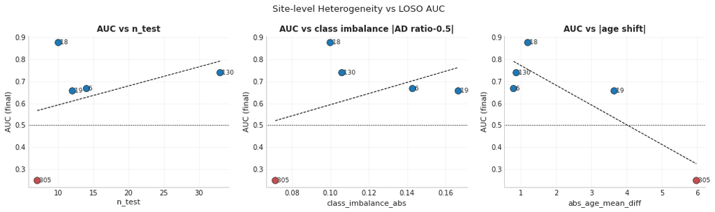

**Interpretation.** Site 305 combines low n_test (7) with the largest age-shift indicator (|Δage|=5.98), which quantitatively supports a heterogeneity-plus-small-sample explanation for its instability.

```python
if artifact_paths["loso_primary_site_metrics"] is None:
    warnings.warn("Cannot derive heterogeneity table without primary LOSO outputs.")
else:
    primary_root = artifact_paths["loso_primary_site_metrics"].parent
    het_rows = []

    for _, row in primary_site.iterrows():
        site_num = int(row["site_num"])
        site_tag = f"site_{site_num:03d}"
        test_path = primary_root / site_tag / "test_subjects.csv"
        train_path = primary_root / site_tag / "train_subjects.csv"
        if not test_path.exists() or not train_path.exists():
            continue

        tdf = pd.read_csv(test_path)
        trdf = pd.read_csv(train_path)
        t_age = pd.to_numeric(tdf.get("Age"), errors="coerce")
        tr_age = pd.to_numeric(trdf.get("Age"), errors="coerce")

        n_cn = int((tdf["ResearchGroup_Mapped"] == "CN").sum())
        n_ad = int((tdf["ResearchGroup_Mapped"] == "AD").sum())
        n_test = len(tdf)
        ad_ratio = n_ad / n_test if n_test else np.nan

        het_rows.append(
            {
                "site": site_num,
                "auc_final": float(row["auc_final"]),
                "balanced_accuracy": float(row["balanced_accuracy"]),
                "n_test": n_test,
                "n_CN_test": n_cn,
                "n_AD_test": n_ad,
                "ad_ratio_test": ad_ratio,
                "class_imbalance_abs": abs(ad_ratio - 0.5) if pd.notna(ad_ratio) else np.nan,
                "age_mean_test": float(t_age.mean()),
                "age_mean_train": float(tr_age.mean()),
                "abs_age_mean_diff": float(abs(t_age.mean() - tr_age.mean())),
            }
        )

    het_df = pd.DataFrame(het_rows).sort_values("site")
    het_df.to_csv(TABLE_DIR / "11_site_heterogeneity_table.csv", index=False)
    display(het_df)

    # Correlation snapshot
    corr_cols = ["auc_final", "n_test", "class_imbalance_abs", "abs_age_mean_diff"]
    corr = het_df[corr_cols].corr(method="spearman")
    display(corr)
    corr.to_csv(TABLE_DIR / "11_site_heterogeneity_spearman_corr.csv")

    fig, axes = plt.subplots(1, 3, figsize=(14.5, 4.3))
    scat_cfg = [
        ("n_test", "AUC vs n_test"),
        ("class_imbalance_abs", "AUC vs class imbalance |AD ratio-0.5|"),
        ("abs_age_mean_diff", "AUC vs |age shift|"),
    ]

    for ax, (xcol, title) in zip(axes, scat_cfg):
        x = het_df[xcol].values
        y = het_df["auc_final"].values
        colors = [COLORS["site305"] if int(s) == FAIL_SITE else COLORS["logreg"] for s in het_df["site"]]
        ax.scatter(x, y, s=90, c=colors, edgecolor="black", linewidth=0.5)
        for _, rr in het_df.iterrows():
            ax.text(rr[xcol], rr["auc_final"], f" {int(rr['site'])}", fontsize=9, va="center")
        if len(x) >= 2 and np.isfinite(x).sum() >= 2:
            xx = np.linspace(np.nanmin(x), np.nanmax(x), 100)
            coef = np.polyfit(x, y, 1)
            ax.plot(xx, np.polyval(coef, xx), color="black", linestyle="--", linewidth=1)
        ax.axhline(0.5, linestyle=":", color="black", linewidth=1)
        ax.set_xlabel(xcol)
        ax.set_ylabel("AUC (final)")
        ax.set_title(title)

    fig.suptitle("Site-level Heterogeneity vs LOSO AUC", fontsize=13)
    fig.tight_layout()
    export_figure(fig, FIG_DIR, "11_site_heterogeneity_vs_auc")
    plt.show()

    row305 = het_df[het_df["site"] == FAIL_SITE]
    if not row305.empty:
        rr = row305.iloc[0]
        display(Markdown(
            f"**Interpretation.** Site {FAIL_SITE} combines low n_test ({int(rr['n_test'])}) with the largest age-shift indicator (|Δage|={rr['abs_age_mean_diff']:.2f}), "
            "which quantitatively supports a heterogeneity-plus-small-sample explanation for its instability."
        ))
```

## 12. Key Takeaways for Coauthors and Revision Wording

The statements below separate supported claims from limitations and exploratory inferences.

```python
takeaways = []

p = _extract_pooled(loso_primary_pooled, "logreg")
s = _extract_pooled(loso_strict_pooled, "logreg")
sv = _extract_pooled(loso_primary_svm_pooled, "svm")

if p is not None:
    takeaways.append(
        f"1. **Supported:** Primary Philips LOSO (logreg) shows pooled AUC={p['pooled_auc_final']:.3f} and pooled balanced accuracy={p['pooled_balanced_accuracy']:.3f} (n={int(p['n_total'])}), consistent with non-trivial within-manufacturer site generalization."
    )
if s is not None:
    takeaways.append(
        f"2. **Supported:** Strict LOSO (sites 6/130) yields pooled AUC={s['pooled_auc_final']:.3f}; this is directionally consistent and should be presented as complementary robustness, not as the main estimate."
    )
if p is not None and sv is not None:
    takeaways.append(
        f"3. **Supported:** SVM sensitivity does not overturn conclusions (pooled AUC={sv['pooled_auc_final']:.3f} vs logreg {p['pooled_auc_final']:.3f}); logreg remains preferable for headline reporting."
    )

takeaways.append(
    "4. **Supported:** LOSO is stronger site-independent internal validation within ADNI than random CV, but it is **not external validation**."
)
takeaways.append(
    "5. **Limitation:** Cross-manufacturer LOSO is not interpretable in this cohort because CN subjects are absent in GE/SIEMENS; claims must remain within Philips-only site generalization."
)
takeaways.append(
    "6. **Site 305 framing:** The failure likely reflects a combination of tiny test size, threshold behavior, ranking inversion, and cohort/protocol heterogeneity; this should be discussed transparently without overclaiming mechanism."
)
takeaways.append(
    "7. **Reviewer response value:** This notebook directly addresses calibration and site-independence concerns with pooled calibration diagnostics, per-site LOSO metrics, and an explicit site-outlier audit."
)

display(Markdown("\n".join(takeaways)))
```

1. **Supported:** Primary Philips LOSO (logreg) shows pooled AUC=0.681 and pooled balanced accuracy=0.625 (n=76), consistent with non-trivial within-manufacturer site generalization.

2. **Supported:** Strict LOSO (sites 6/130) yields pooled AUC=0.665; this is directionally consistent and should be presented as complementary robustness, not as the main estimate.

3. **Supported:** SVM sensitivity does not overturn conclusions (pooled AUC=0.636 vs logreg 0.681); logreg remains preferable for headline reporting.

4. **Supported:** LOSO is stronger site-independent internal validation within ADNI than random CV, but it is **not external validation**.

5. **Limitation:** Cross-manufacturer LOSO is not interpretable in this cohort because CN subjects are absent in GE/SIEMENS; claims must remain within Philips-only site generalization.

6. **Site 305 framing:** The failure likely reflects a combination of tiny test size, threshold behavior, ranking inversion, and cohort/protocol heterogeneity; this should be discussed transparently without overclaiming mechanism.

7. **Reviewer response value:** This notebook directly addresses calibration and site-independence concerns with pooled calibration diagnostics, per-site LOSO metrics, and an explicit site-outlier audit.

## 13. Exported Outputs

Figures and summary tables generated by this notebook are written to:

- `results/revision_bspc_2026/figures_loso_master_q1/`
- `results/revision_bspc_2026/tables_loso_master_q1/`

```python
pngs = sorted(FIG_DIR.glob("*.png"))
pdfs = sorted(FIG_DIR.glob("*.pdf"))
csvs = sorted(TABLE_DIR.glob("*.csv"))

print(f"Exported PNG figures: {len(pngs)}")
for p in pngs:
    print(" -", p)

print(f"\nExported PDF figures: {len(pdfs)}")
for p in pdfs:
    print(" -", p)

print(f"\nExported CSV tables: {len(csvs)}")
for p in csvs:
    print(" -", p)
```

```
Exported PNG figures: 15
 - /home/diego/proyectos/vae_AD/results/revision_bspc_2026/figures_loso_master_q1/03_manufacturer_by_class.png
 - /home/diego/proyectos/vae_AD/results/revision_bspc_2026/figures_loso_master_q1/03_philips_loso_site_composition.png
 - /home/diego/proyectos/vae_AD/results/revision_bspc_2026/figures_loso_master_q1/04_scanner_leakage_context.png
 - /home/diego/proyectos/vae_AD/results/revision_bspc_2026/figures_loso_master_q1/05_primary_loso_triptych.png
 - /home/diego/proyectos/vae_AD/results/revision_bspc_2026/figures_loso_master_q1/05_primary_pooled_roc_pr.png
 - /home/diego/proyectos/vae_AD/results/revision_bspc_2026/figures_loso_master_q1/06_primary_vs_strict_overlap.png
 - /home/diego/proyectos/vae_AD/results/revision_bspc_2026/figures_loso_master_q1/07_logreg_vs_svm_per_site.png
 - /home/diego/proyectos/vae_AD/results/revision_bspc_2026/figures_loso_master_q1/08_primary_calibration.png
 - /home/diego/proyectos/vae_AD/results/revision_bspc_2026/figures_loso_master_q1/09_site305_age_clinical_audit.png
 - /home/diego/proyectos/vae_AD/results/revision_bspc_2026/figures_loso_master_q1/09_site305_prediction_behavior.png
 - /home/diego/proyectos/vae_AD/results/revision_bspc_2026/figures_loso_master_q1/09_site305_protocol_context.png
 - /home/diego/proyectos/vae_AD/results/revision_bspc_2026/figures_loso_master_q1/09_site305_vs_site130_confusion.png
 - /home/diego/proyectos/vae_AD/results/revision_bspc_2026/figures_loso_master_q1/10_connectome_pca_site305.png
 - /home/diego/proyectos/vae_AD/results/revision_bspc_2026/figures_loso_master_q1/10_site305_nearest_neighbor_distances.png
 - /home/diego/proyectos/vae_AD/results/revision_bspc_2026/figures_loso_master_q1/11_site_heterogeneity_vs_auc.png

Exported PDF figures: 15
 - /home/diego/proyectos/vae_AD/results/revision_bspc_2026/figures_loso_master_q1/03_manufacturer_by_class.pdf
 - /home/diego/proyectos/vae_AD/results/revision_bspc_2026/figures_loso_master_q1/03_philips_loso_site_composition.pdf
 - /home/diego/proyectos/vae_AD/results/revision_bspc_2026/figures_loso_master_q1/04_scanner_leakage_context.pdf
 - /home/diego/proyectos/vae_AD/results/revision_bspc_2026/figures_loso_master_q1/05_primary_loso_triptych.pdf
 - /home/diego/proyectos/vae_AD/results/revision_bspc_2026/figures_loso_master_q1/05_primary_pooled_roc_pr.pdf
 - /home/diego/proyectos/vae_AD/results/revision_bspc_2026/figures_loso_master_q1/06_primary_vs_strict_overlap.pdf
 - /home/diego/proyectos/vae_AD/results/revision_bspc_2026/figures_loso_master_q1/07_logreg_vs_svm_per_site.pdf
 - /home/diego/proyectos/vae_AD/results/revision_bspc_2026/figures_loso_master_q1/08_primary_calibration.pdf
 - /home/diego/proyectos/vae_AD/results/revision_bspc_2026/figures_loso_master_q1/09_site305_age_clinical_audit.pdf
 - /home/diego/proyectos/vae_AD/results/revision_bspc_2026/figures_loso_master_q1/09_site305_prediction_behavior.pdf
 - /home/diego/proyectos/vae_AD/results/revision_bspc_2026/figures_loso_master_q1/09_site305_protocol_context.pdf
 - /home/diego/proyectos/vae_AD/results/revision_bspc_2026/figures_loso_master_q1/09_site305_vs_site130_confusion.pdf
 - /home/diego/proyectos/vae_AD/results/revision_bspc_2026/figures_loso_master_q1/10_connectome_pca_site305.pdf
 - /home/diego/proyectos/vae_AD/results/revision_bspc_2026/figures_loso_master_q1/10_site305_nearest_neighbor_distances.pdf
 - /home/diego/proyectos/vae_AD/results/revision_bspc_2026/figures_loso_master_q1/11_site_heterogeneity_vs_auc.pdf

Exported CSV tables: 20
 - /home/diego/proyectos/vae_AD/results/revision_bspc_2026/tables_loso_master_q1/03_site_loso_feasibility_summary.csv
 - /home/diego/proyectos/vae_AD/results/revision_bspc_2026/tables_loso_master_q1/04_scanner_leakage_summary_table.csv
 - /home/diego/proyectos/vae_AD/results/revision_bspc_2026/tables_loso_master_q1/05_primary_loso_site_metrics_table.csv
 - /home/diego/proyectos/vae_AD/results/revision_bspc_2026/tables_loso_master_q1/05_primary_pooled_auc_bootstrap_ci.csv
 - /home/diego/proyectos/vae_AD/results/revision_bspc_2026/tables_loso_master_q1/06_strict_vs_primary_overlap.csv
 - /home/diego/proyectos/vae_AD/results/revision_bspc_2026/tables_loso_master_q1/07_logreg_vs_svm_per_site.csv
 - /home/diego/proyectos/vae_AD/results/revision_bspc_2026/tables_loso_master_q1/07_logreg_vs_svm_pooled.csv
 - /home/diego/proyectos/vae_AD/results/revision_bspc_2026/tables_loso_master_q1/08_primary_calibration_stats.csv
 - /home/diego/proyectos/vae_AD/results/revision_bspc_2026/tables_loso_master_q1/09_site305_clinical_smd.csv
 - /home/diego/proyectos/vae_AD/results/revision_bspc_2026/tables_loso_master_q1/09_site305_clinical_summary.csv
 - /home/diego/proyectos/vae_AD/results/revision_bspc_2026/tables_loso_master_q1/09_site305_subject_roster_with_predictions.csv
 - /home/diego/proyectos/vae_AD/results/revision_bspc_2026/tables_loso_master_q1/09_site305_vs_other_phase_table.csv
 - /home/diego/proyectos/vae_AD/results/revision_bspc_2026/tables_loso_master_q1/09_site305_vs_other_protocol_counts.csv
 - /home/diego/proyectos/vae_AD/results/revision_bspc_2026/tables_loso_master_q1/09_site305_vs_other_sex_table.csv
 - /home/diego/proyectos/vae_AD/results/revision_bspc_2026/tables_loso_master_q1/09_site305_vs_other_slice_table.csv
 - /home/diego/proyectos/vae_AD/results/revision_bspc_2026/tables_loso_master_q1/10_nearest_neighbor_distance_site305_vs_rest.csv
 - /home/diego/proyectos/vae_AD/results/revision_bspc_2026/tables_loso_master_q1/10_site_centroid_distance_table.csv
 - /home/diego/proyectos/vae_AD/results/revision_bspc_2026/tables_loso_master_q1/11_site_heterogeneity_spearman_corr.csv
 - /home/diego/proyectos/vae_AD/results/revision_bspc_2026/tables_loso_master_q1/11_site_heterogeneity_table.csv
 - /home/diego/proyectos/vae_AD/results/revision_bspc_2026/tables_loso_master_q1/executive_summary_loso_master_q1.csv
```